# ANZ Chengdu Data Science Competition

# 1 Introduction

- **Backgroud** The data is related with direct marketing campaigns of a Portuguese banking institution. The marketing campaigns were based on phone calls. The classification goal is to predict if the client will subscribe (yes/no) a term deposit (variable y).
- **Business Problem** is to predict whether the client will subscribe to a term deposit.

# 2 Preparations

## 2.1 Load libraries

```r
library(tidyverse)
library(xgboost)
library(keras)
library(h2o)
library(caret)
library(lme4)
library(ggalluvial)
library(jsonlite)
library(lubridate)
library(knitr)
library(Rmisc)
library(scales)
library(magrittr)
library(vcd)
library(pROC)
```

## 2.2 Load data

```r
set.seed(0)
dev <- read_csv("./data/bank-additional-train.csv")
```

## 2.3 Global Vars & Funs

```r
anz_color1 <- "dodgerblue4"
anz_color2 <- "deepskyblue2"

uf_gridsearch_xgb <- function(data, fold = 10){
  rlt <- tibble(id = 0,
                eta = 0,
                gamma = 0,
                max_depth = 0,
                min_child_weight = 0,
                max_delta_step = 0,
                subsample = 0,
                colsample_bytree = 0,
                colsample_bylevel = 0,
                lambda = 0,
                scale_pos_weight = 0,
                best_iteration = 0,
                best_ntreelimit = 0,
                niter = 0,
                train_error_mean = 0,
                train_error_std = 0,
                test_error_mean = 0,
                test_error_std= 0)[0]

  eta <- c(0.01,0.05) #c(0.01,0.03,0.05,0.1);
  len_eta <- length(eta)
  gamma <- c(0);
  len_gamma <- length(gamma)
  max_depth <- c(4)#c(4,5,6,7,8,9);
  len_max_depth <- length(max_depth)
  min_child_weight <- c(5)#c(1,2,3,4,5,6,7);
  len_min_child_weight <- length(min_child_weight)
  max_delta_step <- 0;
  subsample <- c(.8)#c(1,.9,.8,.7,.6,.5);
  len_subsample <- length(subsample)
  colsample_bytree <- c(.8)#c(1,.9,.8,.7,.6,.5);
  len_colsample_bytree <- length(colsample_bytree)
  colsample_bylevel <- c(.8) #c(1,.9,.8,.7,.6,.5);
  len_colsample_bylevel <- length(colsample_bylevel)
  lambda <- c(0)#c(0,5,10,15,20);
  len_lambda <- length(lambda)
  scale_pos_weight <- c(1)#c(1,.4,.5,.6,.7,.8);
  len_scale_pos_weight <- length(scale_pos_weight)

  total_loop <- len_eta*len_gamma*len_max_depth*len_min_child_weight*len_subsample*len_colsample_bytree*len_colsample_bylevel*len_lambda
  cat("totla loop: ", total_loop, "   ")

  loop_i <- 0
  for(e in 1:len_eta){
    for(g in 1:len_gamma){
      for(md in 1:len_max_depth){
        for(mcw in 1:len_min_child_weight){
          for(ss in 1:len_subsample){
            for(cbt in 1:len_colsample_bytree){
              for(cbl in 1:len_colsample_bylevel){
                for(l in 1:len_lambda){
                  for(spw in 1:len_scale_pos_weight){

                    cat("Round ", loop_i + 1, " / ",total_loop)

                    hp <- list(
                      seed = 0,
                      silent = 1,
                      nthread = 2,
                      booster = "gbtree",
                      objective = "binary:logistic",
                      eval_metric = "auc",

                      eta = eta[e],

                      gamma = gamma[g],
                      max_depth = max_depth[md],
                      min_child_weight = min_child_weight[mcw],
                      max_delta_step = 0,

                      subsample = subsample[ss],
                      colsample_bytree = colsample_bytree[cbt],
                      colsample_bylevel = colsample_bylevel[cbl],

                      lambda = lambda[l],
                      alpha = 0,

                      scale_pos_weight = scale_pos_weight[spw]
                    )

                    fit.cv <- xgb.cv(
                      hp,
                      data,
                      missing = NA,
                      nrounds = 100,
                      nfold = fold,
                      prediction = TRUE,
                      showsd = TRUE,
                      stratified = TRUE,
                      verbose = FALSE,
                      print_every_n = 1,
                      early_stopping_rounds = 10
                    )

                    rlt <- union_all(
                      rlt,
                      tibble(id = loop_i + 1,
                             eta = eta[e],
                             gamma = gamma[g],
                             max_depth = max_depth[md],
                             min_child_weight = min_child_weight[mcw],
                             max_delta_step = 0,
                             subsample = subsample[ss],
                             colsample_bytree = colsample_bytree[cbt],
                             colsample_bylevel = colsample_bylevel[cbl],
                             lambda = lambda[l],
                             scale_pos_weight = scale_pos_weight[spw],
                             best_iteration = fit.cv$best_iteration,
                             best_ntreelimit = fit.cv$best_ntreelimit,
                             niter = fit.cv$niter,
                             train_error_mean = fit.cv$evaluation_log[fit.cv$best_iteration,]$train_auc_mean,
                             train_error_std = fit.cv$evaluation_log[fit.cv$best_iteration,]$train_auc_std,
                             test_error_mean = fit.cv$evaluation_log[fit.cv$best_iteration,]$test_auc_mean,
                             test_error_std= fit.cv$evaluation_log[fit.cv$best_iteration,]$test_auc_std)
                    )
                    loop_i <- loop_i + 1
                  }
                }
              }
            }
          }
        }
      }
    }
  }

  cat("Grid search done")
  return(rlt)
}
```

# 3 Peek at the dataset

## 3.1 General info

```r
glimpse(dev)
```

```
## Observations: 37,069
## Variables: 21
## $ age            <dbl> 32, 41, 32, 37, 38, 35, 42, 42, 34, 45, 37, 31, 3…
## $ job            <chr> "management", "admin.", "admin.", "admin.", "admi…
## $ marital        <chr> "married", "married", "married", "married", "divo…
## $ education      <chr> "professional.course", "high.school", "university…
## $ default        <chr> "unknown", "no", "no", "no", "no", "no", "unknown…
## $ housing        <chr> "no", "yes", "yes", "unknown", "no", "unknown", "…
## $ loan           <chr> "no", "yes", "no", "unknown", "no", "unknown", "n…
## $ contact        <chr> "cellular", "cellular", "cellular", "cellular", "…
## $ month          <chr> "jul", "apr", "may", "jul", "jul", "jul", "may", …
## $ day_of_week    <chr> "mon", "mon", "mon", "thu", "tue", "tue", "wed", …
## $ duration       <dbl> 565, 982, 188, 56, 419, 78, 378, 236, 511, 359, 1…
## $ campaign       <dbl> 4, 1, 2, 3, 8, 4, 1, 3, 1, 1, 3, 1, 3, 1, 1, 1, 4…
## $ pdays          <dbl> 999, 999, 999, 999, 999, 999, 999, 999, 999, 999,…
## $ previous       <dbl> 0, 0, 0, 0, 0, 0, 0, 0, 0, 0, 0, 1, 0, 0, 0, 1, 0…
## $ poutcome       <chr> "nonexistent", "nonexistent", "nonexistent", "non…
## $ emp.var.rate   <dbl> 1.4, -1.8, -1.8, 1.4, 1.4, 1.4, 1.1, 1.1, 1.4, -3…
## $ cons.price.idx <dbl> 93.918, 93.075, 92.893, 93.918, 93.918, 93.918, 9…
## $ cons.conf.idx  <dbl> -42.7, -47.1, -46.2, -42.7, -42.7, -42.7, -36.4, …
## $ euribor3m      <dbl> 4.962, 1.405, 1.299, 4.968, 4.961, 4.961, 4.859, …
## $ nr.employed    <dbl> 5228.1, 5099.1, 5099.1, 5228.1, 5228.1, 5228.1, 5…
## $ y              <chr> "no", "no", "no", "no", "no", "no", "no", "no", "…
```

```r
kable(head(dev[,1:10],2))
```

| age | job | marital | education | default | housing | loan | contact | month | day_of_week |
| --- | --- | --- | --- | --- | --- | --- | --- | --- | --- |
| 32 | management | married | professional.course | unknown | no | no | cellular | jul | mon |
| 41 | admin. | married | high.school | no | yes | yes | cellular | apr | mon |

## 3.2 Distribution of target variable

- Learn from the plot: Highly unbalanced distribution.
- Impact: choice of loss function/performance metric; hyper-parameter tuning

[figure not shown]

Safely transform variable ‘y’ to binary type

```r
dev$y <- ifelse(dev$y == "yes",1,0)
```

## 3.3 Missing value check

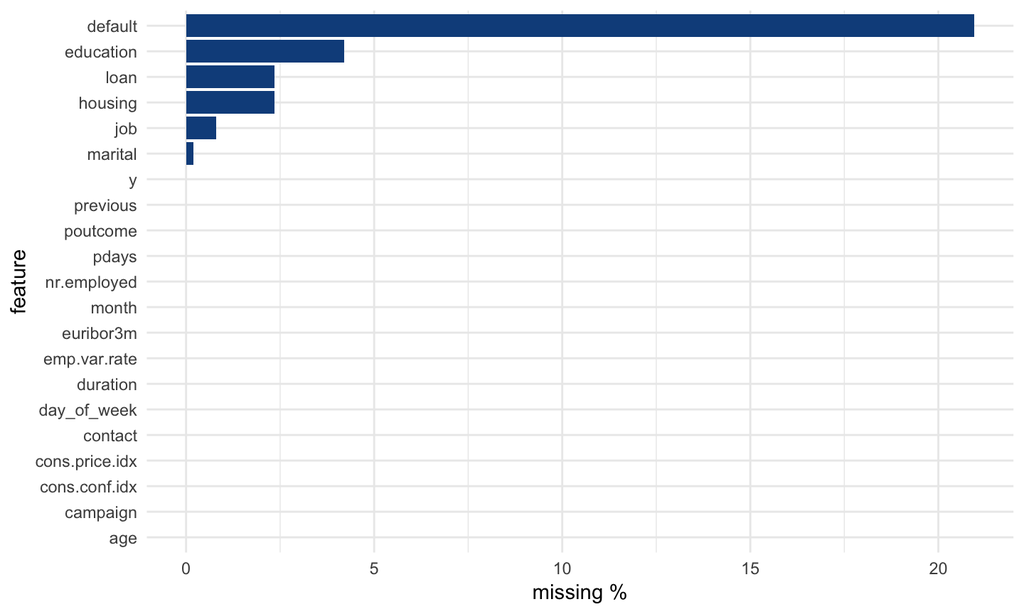

DBSCAN clustering on client data

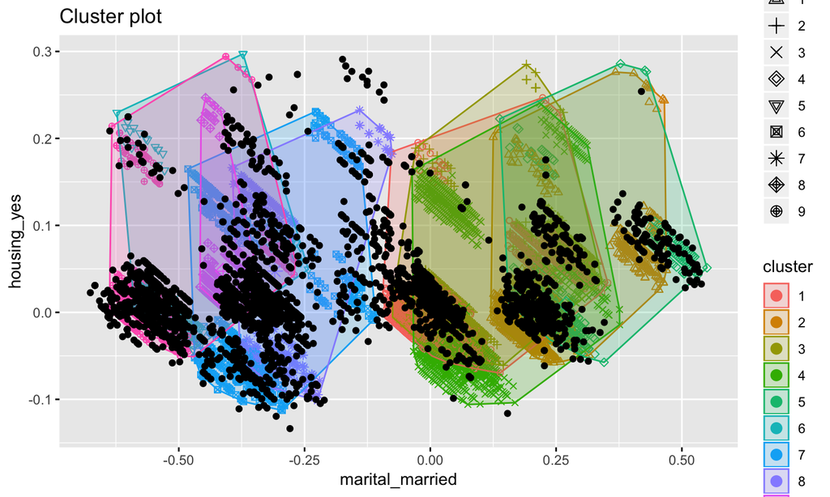

```r
clients <- dev %>% select(age, job, marital, education, default, housing, loan)
clients_gd <- clients %>% filter(default!="unknown",education!="unknown",loan!="unknown",housing!="unknown",job!="unknown",marital!="unknown")
clients_gd$age <- scale(clients_gd$age)

M_C <- as.tibble(model.matrix(~.-1, data = clients_gd) )

library(fpc); library(factoextra); library(dbscan)
MinPts = 100
eps = 1.1
#kNNdistplot(M_C, k = MinPts)
#abline(h = eps, lty = 2)

clsts <-
  fpc::dbscan(data = M_C,
              eps = eps,
              MinPts = MinPts,
              scale = FALSE)
#clsts
#range(clsts$cluster)       #check the class, 0 represent outlier
fviz_cluster(clsts, M_C, stand = FALSE, axes = c(13,21),
             geom = "point",
             xlab = "marital_married",
             ylab = "housing_yes")
```

## 3.4 Duplication check

- Create md5 key of the combinition of all attributes for each record.
- **Note** no primary key for unqiue user.

```r
dev$md5key <- apply(dev %>% select(-one_of("y")), 1, function(x){openssl::md5(str_c(x,collapse = ""))}) #generate 'md5' key for each sample
dev_dup <- dev %>% group_by(md5key) %>% dplyr::count() %>% filter(n > 1)            # find out duplicate records
if(nrow(dev %>% filter(md5key %in% dev_dup$md5key) %>% select(md5key,y) %>%         # make sure duplicate records has same 'y'
        group_by(md5key) %>% dplyr::summarise(sum_y = sum(y)) %>% filter(sum_y == 1)) == 0){
  cat("There are ", nrow(dev_dup), " records have duplicate, but none of them has different 'y'")
}
```

```
## There are  11  records have duplicate, but none of them has different 'y'
```

```r
kable(dev %>% filter(md5key == "4bd6f9da6febbb8a4bb4206f0207020b"))
```

| age | job | marital | education | default | housing | loan | contact | month | day_of_week | duration | campaign | pdays | previous | poutcome | emp.var.rate | cons.price.idx | cons.conf.idx | euribor3m | nr.employed | y | md5key |
| --- | --- | --- | --- | --- | --- | --- | --- | --- | --- | --- | --- | --- | --- | --- | --- | --- | --- | --- | --- | --- | --- |
| 39 | admin. | married | university.degree | no | no | no | cellular | nov | tue | 123 | 2 | 999 | 0 | nonexistent | -0.1 | 93.2 | -42 | 4.153 | 5195.8 | 0 | 4bd6f9da6febbb8a4bb4206f0207020b |
| 39 | admin. | married | university.degree | no | no | no | cellular | nov | tue | 123 | 2 | 999 | 0 | nonexistent | -0.1 | 93.2 | -42 | 4.153 | 5195.8 | 0 | 4bd6f9da6febbb8a4bb4206f0207020b |

## 3.5 Time series check

Know from the introduction, the data is ordered by date (from May 2008 to November 2010)

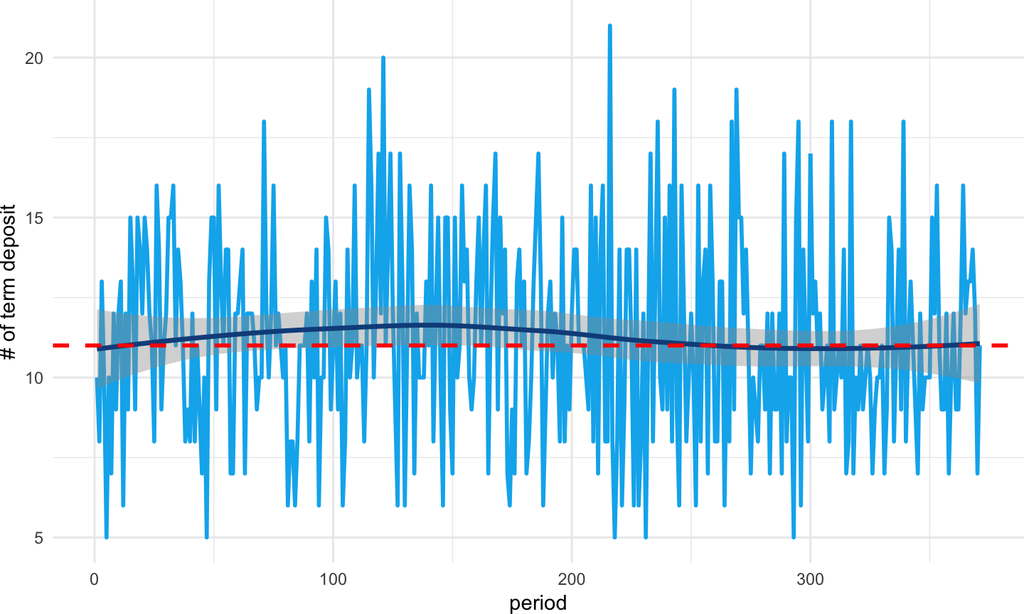

```r
time_series_check <- function(dt, duration){
  dt$seq <- c(1:nrow(dt))
  dt$seq_duration <- ceiling(dt$seq / duration)
  agv_deal <- floor(mean((dt %>% group_by(seq_duration) %>% dplyr::summarise(sum_y = sum(y)))$sum_y))
  dt %>%
    group_by(seq_duration) %>%
    dplyr::summarise(sum_y = sum(y)) %>%
    ggplot(aes(x = seq_duration, y = sum_y)) +
    geom_line(size = 1, colour = anz_color2) +
    labs(x = "period", y = "# of term deposit") +
    geom_smooth(method = "loess", colour = anz_color1, size = 1.2) +
    geom_hline(yintercept = agv_deal, colour = "red", size = 1, linetype = 2) +
    theme_minimal() +
    theme(plot.margin = unit(c(0,0,0,0),"cm"))
}

time_series_check(dev, 100)
```

# 4 EDA & Data Tidy

## 4.1 Age

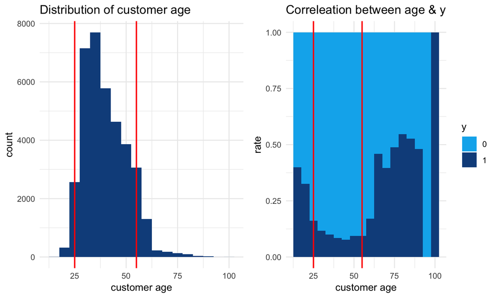

## 4.2 Client categrical attributes

- Categrical variables: job,marital,education,default,housing,loan,contact
- contact

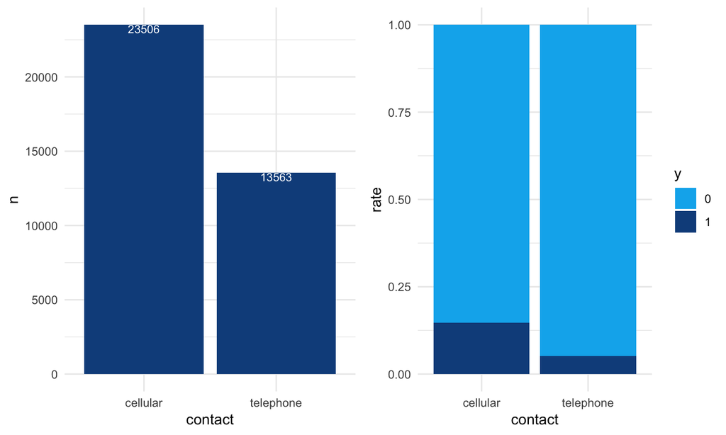

```r
p1 <-
  dev %>% group_by(contact) %>% dplyr::count() %>%
    ggplot(aes(x = contact, y = n)) +
    geom_bar(stat = "identity", fill = anz_color1) +
    geom_text(aes(label = n),vjust = 1, colour = "white", size = 3) +
    labs(x = "contact") +
    theme_minimal()

p2 <- dev %>%
  ggplot(aes(x = contact, fill = as.factor(y))) +
  geom_bar(position = "fill") +
  scale_fill_manual(values=c(anz_color2, anz_color1), name = "y") +
  labs(x = "contact", y = "rate") +
  theme_minimal()

multiplot(p1,p2,cols = 2)
```

- Use ‘job’ as an example:

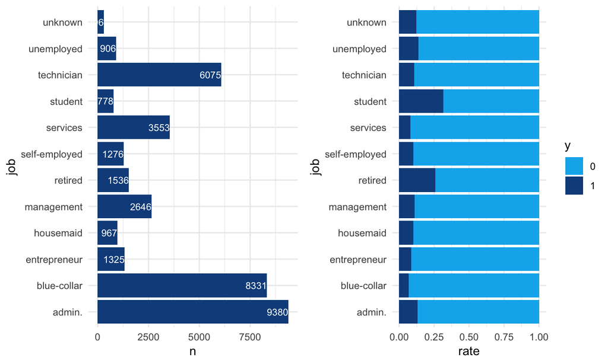

## 4.3 Alluvial diagram for categrical variables

- Useful for discovering of multi-feature interactions.(similar to partial correlation analysis for continous target)
- Conducting Chi-square test for target variable and categrical attributes

```r
(catVars <-
  tibble(var_name = c("job","marital","education","default","housing","loan","contact"),
         nm_unique_values = sapply(dev %>% select(c("job","marital","education","default","housing","loan","contact")),
                                   function(x){length(unique(x))}),
         chi_test_pValue = c(chisq.test(xtabs(~y+job, data = dev), correct = T)$p.value,
                             chisq.test(xtabs(~y+marital, data = dev), correct = T)$p.value,
                             chisq.test(xtabs(~y+education, data = dev), correct = T)$p.value,
                             chisq.test(xtabs(~y+default, data = dev), correct = T)$p.value,
                             chisq.test(xtabs(~y+housing, data = dev), correct = T)$p.value,
                             chisq.test(xtabs(~y+loan, data = dev), correct = T)$p.value,
                             chisq.test(xtabs(~y+contact, data = dev), correct = T)$p.value)) %>%
    arrange(chi_test_pValue))
```

```
## # A tibble: 7 x 3
##   var_name  nm_unique_values chi_test_pValue
##   <chr>                <int>           <dbl>
## 1 job                     12       3.73e-184
## 2 contact                  2       1.76e-168
## 3 default                  3       3.96e- 81
## 4 education                8       2.44e- 33
## 5 marital                  4       1.68e- 24
## 6 housing                  3       1.39e-  1
## 7 loan                     3       4.36e-  1
```

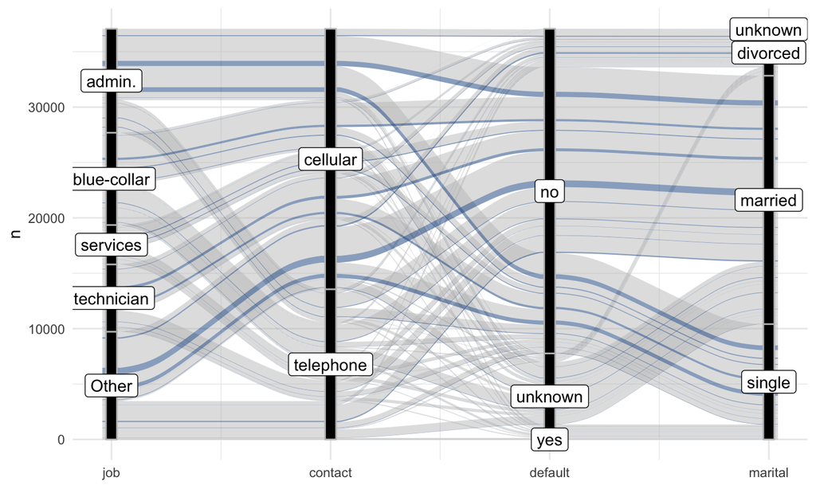

```r
dev %>%
  select(c("job","contact","default","marital")) %>%
  dplyr::mutate_all(factor) %>%
  dplyr::mutate_all(fct_lump,4) %>%
  bind_cols(tibble(deposit = ifelse(dev$y == 0, "no","yes") %>% factor)) %>%
  na.omit() %>%
  group_by_all() %>%
  dplyr::count() %>%
  ggplot(aes(y = n,
             axis1 = job, axis2 = contact, axis3 = default,
             axis5 = marital)) +
  geom_alluvium(aes(fill = deposit), width = 1/12) +
  scale_fill_manual(values=c("gray77", anz_color1), name = "y") +
  geom_stratum(width = 1/20, fill = "black", color = "grey") +
  geom_label(stat = "stratum", label.strata = TRUE) +
  theme_minimal() +
  scale_x_continuous(breaks = 1:4, labels = c("job", "contact", "default",
                                               "marital")) +
  theme(legend.position = "none")
```

## 4.4 Variables: duration, month, day_of_week

```r
cat("There are ", length(dev$y[dev$duration == 0]), "rows with duration equal 0")
```

```
## There are  4 rows with duration equal 0
```

- **Note** as I can’t identify unique user in this dataset, so I assmue each single sample corresponding to a single contact to a unique client. In the realistic situation, i will be tend to collect the data at single contact level, each client can has several contact history, thus the best model for the data would be recurrent nueral network(RNN).
- Learn from the plot: log1p(duration) are normally distributed

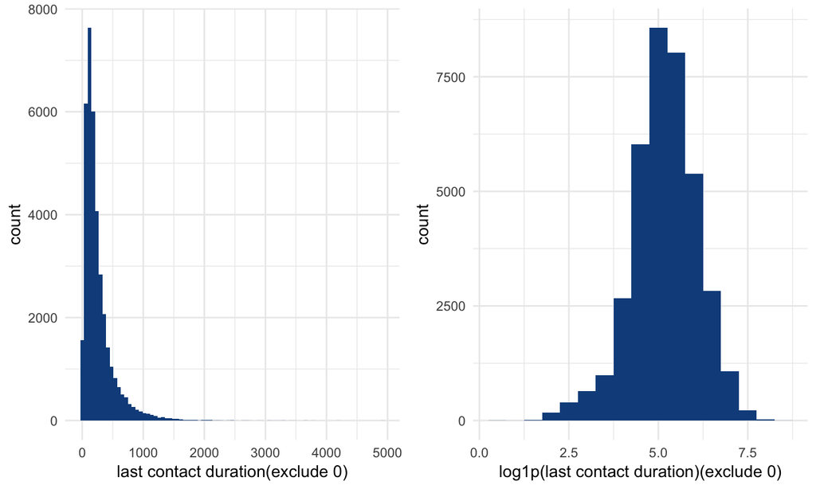

```r
dev$log_duration <- log1p(dev$duration)
```

As month(last contact month of year), day_of_week are the only variables related to time type, there is a question as whether the different month/day_of_week impact the conversation.

- Learn from the plot: we need to investigate what cause the big defference of contact amount by month

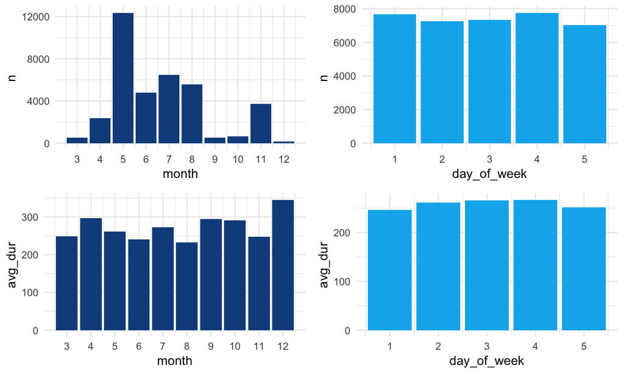

## 4.5 Variables: campain related

- **campaign** - number of contacts performed during this campaign and for this client
- **previous** - number of contacts performed before this campaign
- **pdays** - number of days that passed by after the client was last contacted from a previous campaign
- **poutcome** - outcome of the previous marketing campaign
- combine these attributes

```r
dev %<>% mutate(
  is_previous = ifelse(previous == 0, 0, 1),
  is_pdays = ifelse(pdays == 999, 0, 1),
  is_contacted = ifelse(is_pdays == 0 & is_previous == 0, "in_this_compain",   #table(dev$is_pdays, dev$is_previous)
                        ifelse(is_pdays == 1 & is_previous == 1, "last_contacted",
                               ifelse(is_pdays == 0 & is_previous == 1, "before_last_contacted",NA))),
  clt_cmp_status = str_c(is_contacted,"_",poutcome)
)
kable(dev %>% group_by(is_contacted, poutcome) %>% dplyr::summarise(n = n(), deals = sum(y)) %>% dplyr::mutate(rate = round(deals / n, 3)))
```

| is_contacted | poutcome | n | deals | rate |
| --- | --- | --- | --- | --- |
| before_last_contacted | failure | 3690 | 477 | 0.129 |
| in_this_compain | nonexistent | 32018 | 2810 | 0.088 |
| last_contacted | failure | 130 | 69 | 0.531 |
| last_contacted | success | 1231 | 805 | 0.654 |

Learn from plot: if the client was contacted during previous campaign, (s)he will more likely to subscribe term deposit this time. More contacted not means closer to success.

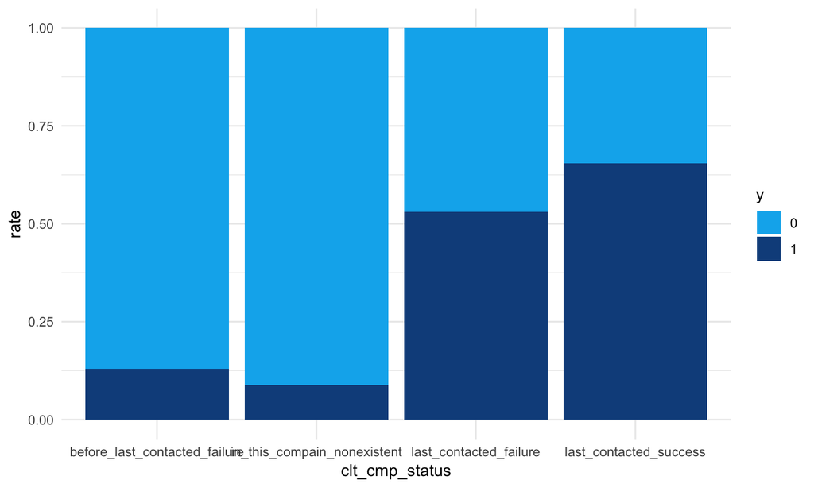

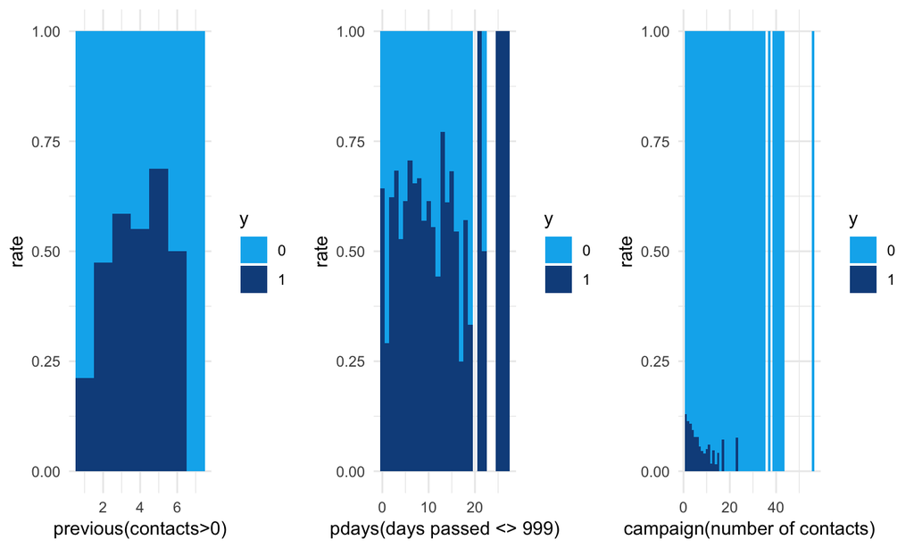

## 4.6 Variables: social and economic context attributes

- Correlation analysis

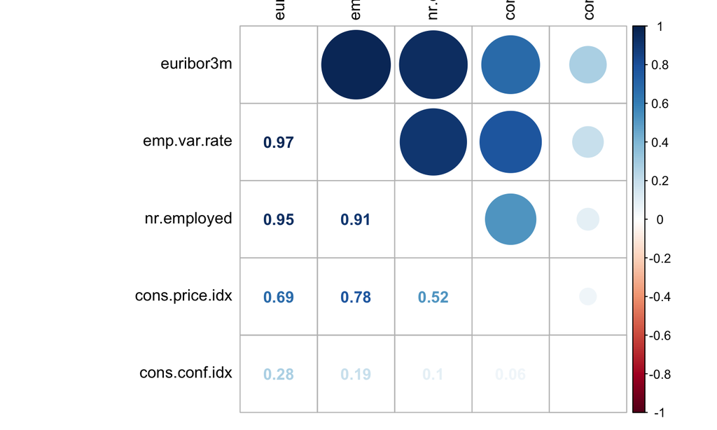

```r
cor_numVar <- stats::cor(dev %>%
                           select(one_of(c("emp.var.rate","cons.price.idx","cons.conf.idx","euribor3m","nr.employed"))),
                         use = "pairwise.complete.obs")

cor_sorted <- as.matrix(sort(cor_numVar[,'euribor3m'], decreasing = TRUE))

CorHigh <- names(which(apply(cor_sorted, 1, function(x) abs(x)>0.1)))
cor_numVar <- cor_numVar[CorHigh, CorHigh]

corrplot::corrplot.mixed(cor_numVar, tl.col="black", tl.pos = "lt",mar = c(0, 0,0, 0))
```

PCA & orthogonal transformation for emp.var.rate, euribor3m, nr.employed, cons.price.idx

```r
data_raw <- dev %>% select(one_of(c("emp.var.rate","cons.price.idx","euribor3m","nr.employed")))
data_scale <- scale(data_raw,scale=T)              #normalization
cov_data <- cov(data_scale)                        #covariance matrix

fea <- eigen(cov_data)                             #calculate feature value and vector
A <- fea$vectors                                   #orthogonal matrix
data_scale_new <- data_scale %*% A                 #orthogonal transformation
dev$emp.var.rate <- data_scale_new[,1]
dev$cons.price.idx <- data_scale_new[,2]
dev$euribor3m <- data_scale_new[,3]
dev$nr.employed <- data_scale_new[,4]
cor(data_scale_new)
```

```
##               [,1]          [,2]          [,3]          [,4]
## [1,]  1.000000e+00 -1.583164e-18 -9.477296e-17  8.077353e-16
## [2,] -1.583164e-18  1.000000e+00  7.127551e-16 -1.932096e-15
## [3,] -9.477296e-17  7.127551e-16  1.000000e+00 -5.524444e-16
## [4,]  8.077353e-16 -1.932096e-15 -5.524444e-16  1.000000e+00
```

# 5 Dataset split into train,validation(k-fold),test

```r
set.seed(1000)
# split into 'train_val' & 'test'
total_seq <- c(1:nrow(dev))
seq_lb <- dev$y
lb0_seq <- total_seq[seq_lb == 0]
lb1_seq <- total_seq[seq_lb == 1]
len_lb0_seq <- length(lb0_seq)
len_lb1_seq <- length(lb1_seq)

splt_rate <- c(0.8,0.2)
attr(splt_rate,"setType") <- c("train_val","test")
attr(splt_rate,"type_len_0") <- c(floor(len_lb0_seq * splt_rate))
attr(splt_rate,"type_len_1") <- c(floor(len_lb1_seq * splt_rate))

lb0_seq_suffle <- lb0_seq[sample(1:len_lb0_seq,size = len_lb0_seq, replace = F)]
lb1_seq_suffle <- lb1_seq[sample(1:len_lb1_seq,size = len_lb1_seq, replace = F)]

train_val_seq <- c(lb0_seq_suffle[1:attr(splt_rate,"type_len_0")[1]], lb1_seq_suffle[1:attr(splt_rate,"type_len_1")[1]])
train_val_seq <- train_val_seq[sample(1:length(train_val_seq),size = length(train_val_seq), replace = F)]
test_seq <- c(lb0_seq_suffle[(attr(splt_rate,"type_len_0")[1]+1):(sum(attr(splt_rate,"type_len_0")[1:2]))],lb1_seq_suffle[(attr(splt_rate,"type_len_1")[1]+1):(sum(attr(splt_rate,"type_len_1")[1:2]))])
test_seq <- test_seq[sample(1:length(test_seq),size = length(test_seq), replace = F)]

cat("There are ", length(train_val_seq), " rows for train/val, and ", length(test_seq), " rows for test.")
```

```
## There are  29654  rows for train/val, and  7413  rows for test.
```

# 6 Model - XGBoost

## 6.1 Feature engineering

- Replace ‘unknown’ to NA
- Transform data structure into spase matrix
- Split dataset ‘dev’ into train, val(k-fold), test

```
## The infor of train dataset -
```

```
## xgb.DMatrix  dim: 23722 x 56  info: label  colnames: yes
```

```
## The infor of validation dataset -
```

```
## xgb.DMatrix  dim: 5930 x 56  info: label  colnames: yes
```

```
## The infor of test dataset -
```

```
## xgb.DMatrix  dim: 7413 x 56  info: label  colnames: yes
```

## 6.2 Model buid and tuning

```r
data <- dtrain_val
gs_rlt <- uf_gridsearch_xgb(dtrain_val,5)
```

```
## totla loop:  2    Round  1  /  2Round  2  /  2Grid search done
```

```r
#write_csv(gs_rlt,"./data/gridSearch_xgb_auc.csv")
```

Check the hyper-parameters of lowest test_error_mean

```r
(gs_rlt_top10 <- gs_rlt %>% filter(!is.na(eta)) %>%
  select(test_error_mean,test_error_std,train_error_mean,train_error_std,2:12) %>%
  dplyr::arrange((test_error_mean+test_error_std)) %>% top_n(10))
```

```
## # A tibble: 2 x 15
##   test_error_mean test_error_std train_error_mean train_error_std   eta
##             <dbl>          <dbl>            <dbl>           <dbl> <dbl>
## 1           0.941        0.00447            0.944        0.000902  0.01
## 2           0.948        0.00461            0.954        0.00104   0.05
## # … with 10 more variables: gamma <dbl>, max_depth <dbl>,
## #   min_child_weight <dbl>, max_delta_step <dbl>, subsample <dbl>,
## #   colsample_bytree <dbl>, colsample_bylevel <dbl>, lambda <dbl>,
## #   scale_pos_weight <dbl>, best_iteration <int>
```

Train the xgb model with selected parameters

```r
#best_param <-  gs_rlt %>% top_n(1,desc(test_error_mean + test_error_std)) %>% select(test_error_mean,test_error_std,train_error_mean,train_error_std,2:12)
xgb.params <- list(seed = 0,
                  silent = 1,
                  nthread = 2,
                  booster = "gbtree",
                  objective = "binary:logistic",
                  eval_metric = "auc",

                  eta = 0.05,

                  gamma = 0,
                  max_depth = 4,
                  min_child_weight = 5,
                  max_delta_step = 0,

                  subsample = .8,
                  colsample_bytree = .8,
                  colsample_bylevel = .7,

                  lambda = 20,
                  alpha = 0,

                  scale_pos_weight = 1)
fit.xgb <- xgb.train(
  params = xgb.params,
  data = dtrain,
  watchlist = list(train = dtrain, val = dval),
  print_every_n = 100,
  early_stopping_rounds = 100,
  nrounds = 1000,
  verbose = TRUE)
```

[output not shown]

Check the information of trained xgb model

```
## The best score(val_error) is:  0.95011 ; and the best iteration is:  433
```

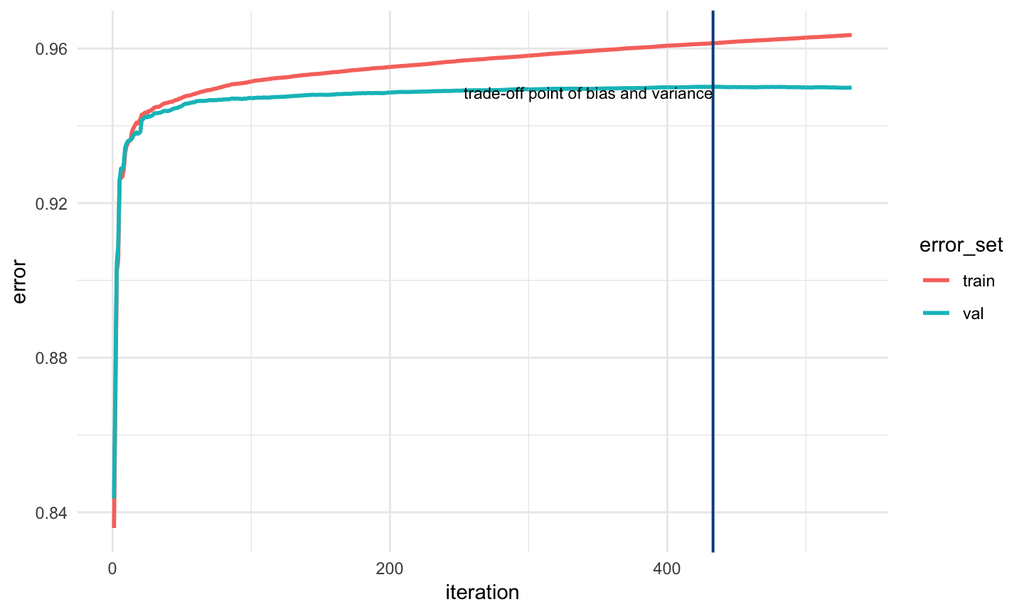

```r
iter.error <-  data.frame(iter = rep(1:fit.xgb$niter,time=2),
                          error_set = rep(c("train","val"),each=fit.xgb$niter),
                          error_p0 = c(fit.xgb$evaluation_log$train_auc,fit.xgb$evaluation_log$val_auc))
ggplot(data = iter.error, aes(x = iter, y = error_p0, colour = error_set)) +
  geom_line(size = 1) +
  labs(x = "iteration", y = "error") +
  geom_vline(xintercept = fit.xgb$best_iteration, colour = anz_color1, size = .7) +
  geom_text(aes(label = ifelse(iter == fit.xgb$best_iteration & error_set == "val","trade-off point of bias and variance","")),size = 3, vjust = 1, hjust = 1, colour = "black") +
  theme(legend.position = "none") +
  theme_minimal()
```

Check the importance of variables

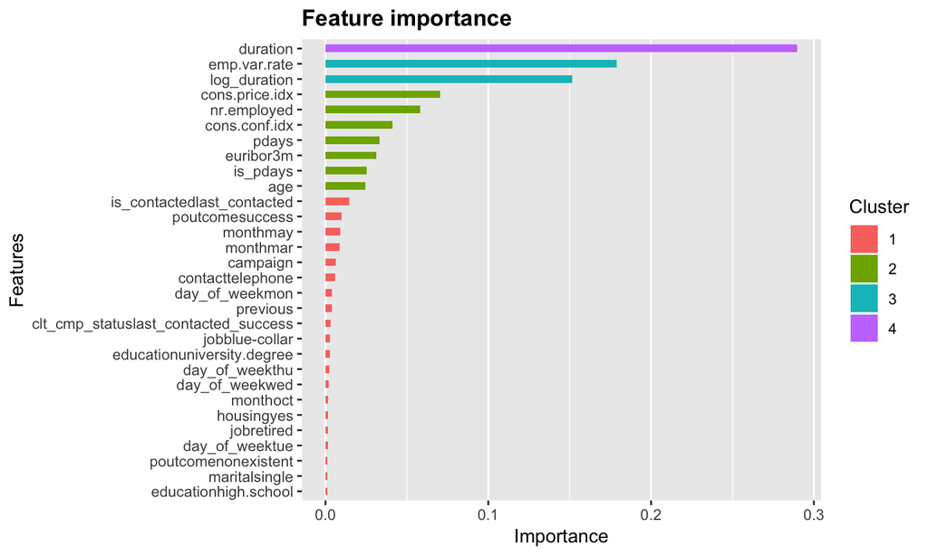

```r
impt.xgb <- xgb.importance(feature_names = fit.xgb$feature_names, model = fit.xgb)
xgb.ggplot.importance(importance_matrix = impt.xgb,top_n = min(30,fit.xgb$nfeatures), measure =  "Gain")
```

## 6.3 Validate on ‘test’ dataset

```r
pred_test_xgb <- predict(fit.xgb, dtest, ntreelimit = fit.xgb$best_iteration)
pred_test_bin_xgb <- ifelse(pred_test_xgb > .5, 1, 0)
conf_mtx <- table(pred_test_bin_xgb, label_test)
acc_xgb <- round(sum(conf_mtx[1,1]+conf_mtx[2,2]) / length(pred_test_bin_xgb),4)
conf_mtx
```

```
##                  label_test
## pred_test_bin_xgb    0    1
##                 0 6341  384
##                 1  240  448
```

```
## The predict accuracy is:  0.9158
```

# 7 Model - Nueral network (TensorFlow/Keras)

## 7.1 Feature engineering

- normalization
- vecterization
- split into train and val

```
## The infor of train dataset -
```

```
## [1] 23722    62
```

```
## The infor of validation dataset -
```

```
## [1] 5930   62
```

```
## The infor of test dataset -
```

```
## [1] 7413   62
```

## 7.2 Model buid and tuning

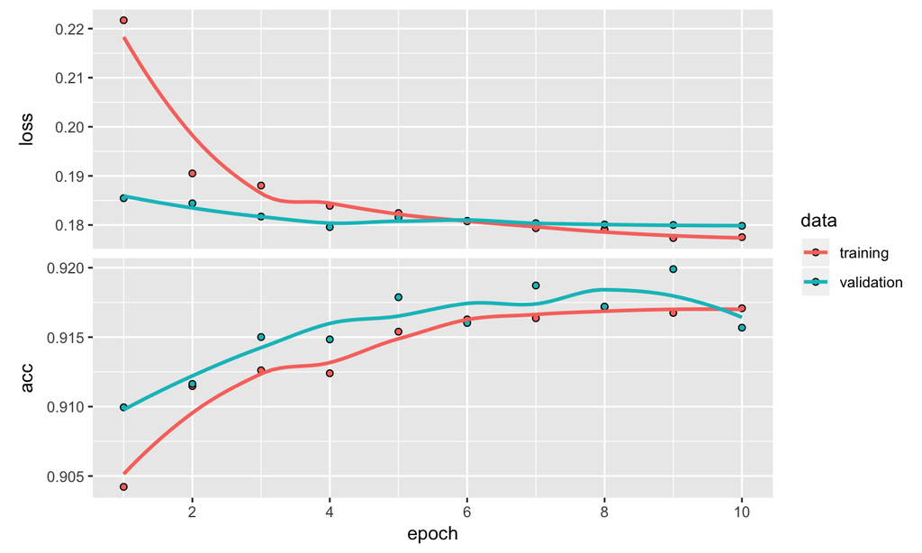

```r
bs <- 64
in_sp <- dim(M_train_x)[[2]]
model <- keras_model_sequential() %>%
  layer_dense(units = 64, activation = "relu", input_shape = in_sp) %>%
  layer_dropout(rate = 0.2) %>%
  layer_dense(units = 32, activation = "relu") %>%
  layer_dropout(rate = 0.1) %>%
  layer_dense(units = 1, activation = "sigmoid")
model %>% compile(
  optimizer = optimizer_rmsprop(lr = 0.001),                    #optimizer_rmsprop
  loss = loss_binary_crossentropy,                              #loss_binary_crossentropy
  metrics = c("accuracy")                                       #metric_binary_accuracy
)

# start training
history <- model %>% fit(
  M_train_x,
  train_y,
  validation_data = list(M_val_x, val_y),
  shuffle = TRUE,
  verbose = TRUE,
  batch_size = bs,
  epochs = 10
)

#str(history)    #start to overfit after 2nd epoch
#history$params
#history$metrics
plot(history)
```

## 7.3 Validate on ‘test’ dataset

```r
pred_test_keras <- model %>% predict(M_test_x)
pred_test_keras <- pred_test_keras[,1]
pred_test_bin_keras <- ifelse(pred_test_keras > .5, 1, 0)
conf_mtx_keras <- table(pred_test_bin_keras, label_test)
acc_keras <- model %>% evaluate(M_test_x,test_y,batch_size = bs)
acc_keras <- acc_keras[2][[1]]
conf_mtx_keras
```

```
##                    label_test
## pred_test_bin_keras    0    1
##                   0 6378  441
##                   1  203  391
```

```
## The predict accuracy is:  0.9131256
```

# 8 Final model selection - XGBoost vs Keras

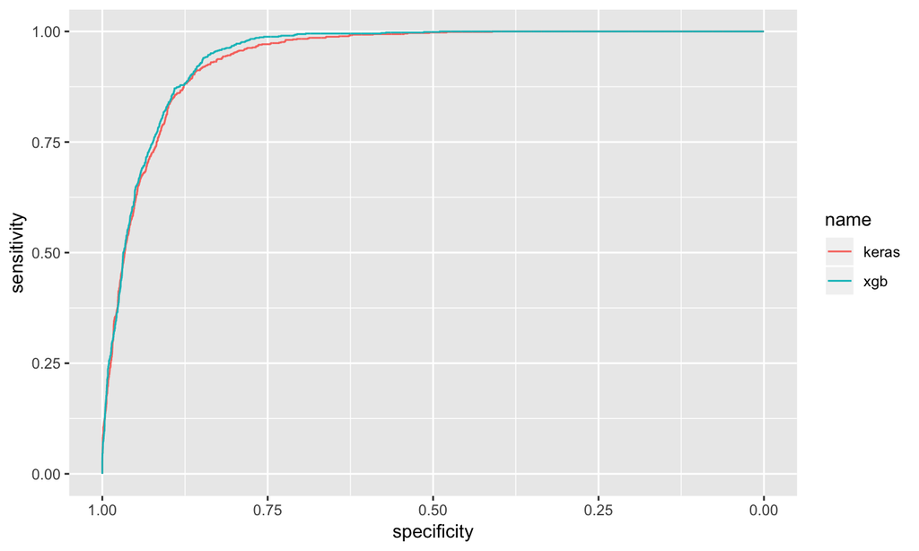

```
## AUC of xgb model is: 0.9466564  and AUC of keras model is: 0.941486
```

```
## The confusion matrix of keras model:
```

```
##                    label_test
## pred_test_bin_keras    0    1
##                   0 6378  441
##                   1  203  391
```

```
## The confusion matrix of xgboost:
```

```
##                  label_test
## pred_test_bin_xgb    0    1
##                 0 6341  384
##                 1  240  448
```

```r
ds.pred.rlt <- data.frame(acc = label_test, xgb_score = pred_test_xgb, keras_score = pred_test_keras)
roc_xgb <- pROC::roc(as.factor(ds.pred.rlt$acc),ds.pred.rlt$xgb_score)
roc_keras <- pROC::roc(as.factor(ds.pred.rlt$acc),ds.pred.rlt$keras_score)
g2 <- ggroc(list(xgb=roc_xgb,keras=roc_keras))  # x(FPR) = FP / (TN+FP); y(TPR) = TP / (TP+FN)
g2
```

# 9 Business Suggestion

- Data collection:

```r
dcSap <- tibble(client_id = c(1,1,1,2,2,3,4,4),
                client_attrs = c("client1","client1","client1","client2","client2","client3","client4","client4"),
                contact_his_id = c(1,2,3,1,2,1,1,2),
                contact_his_infor = c("cl1_ch1","cl1_ch2","cl1_ch3","cl2_ch1","cl2_ch2","cl3_ch1","cl4_ch1","cl1_ch2"),
                final_y = c(0,0,1,0,0,0,0,1)
                )
dcSap
```

```
## # A tibble: 8 x 5
##   client_id client_attrs contact_his_id contact_his_infor final_y
##       <dbl> <chr>                 <dbl> <chr>               <dbl>
## 1         1 client1                   1 cl1_ch1                 0
## 2         1 client1                   2 cl1_ch2                 0
## 3         1 client1                   3 cl1_ch3                 1
## 4         2 client2                   1 cl2_ch1                 0
## 5         2 client2                   2 cl2_ch2                 0
## 6         3 client3                   1 cl3_ch1                 0
## 7         4 client4                   1 cl4_ch1                 0
## 8         4 client4                   2 cl1_ch2                 1
```

- Predictive: do we need to follow up a spicific client any more?
- Business optimization: efficiency improvement